# Modelo de agentes ariadnaNL (NetLogo)

Grupo covid19UNGS

22 agosto, 2020

## Descripción del modelo

- Un modelo de agentes para covid19 con redes bipartitas usando NetLogo
- El objetivo es modelar la epidemia de #covid19 utilizando una red de contactos que se aproxime a las redes de contacto reales. Los individuos modelados mediante agentes tienen una casa y un trabajo, que son siempre los mismos, y constituyen su red bipartita. Ademas tienen un tiempo de viaje donde tienen la posibilidad de interaccionar con otras personas. Cuando se supera la cantidad de camas de hospitalizacion la mortalidad de los hospitalizados aumenta de acuerdo a un parámetro.
- Los individuos tienen distintos estados que determinan la evolución de la epidemia. Los estados son:
  - **Susceptible** : Individuo susceptible de ser infectado
  - **Latente** : Individuo infectado que todavía no desarrolló carga viral por lo tanto no infecta a otros
  - **Presintomático**: Individuo que no tiene síntomas pero que ya tiene carga viral por lo tanto infecta
  - **Asintomático** : Luego del período Presintomático permanece sin síntomas
  - **Sintomático** : Luego del período Presintomático desarrolla síntomas
  - **Hospitalizado** : Luego de un período de pre-hospitalización es hospitalizado
  - **Infectado leve**: Como tiene síntomas leves permanece en la casa
  - **Fallecido** : Fallece luego de un período de internación o luego del período de pre-hospitalización
  - **Recuperado** : Se recupera de la enfermedad y no puede se contagiado nuevamente
- Los parámetros más importantes son:
  - **Beta**: es la tasa de infección/transmisión, los individuos Susceptibles se infectan en su casa o en el trabajo de acuerdo a esta tasa, a la cantidad de horas que están en estos lugares y proporcionalmente a la cantidad de individuos infectados en cada uno de estos sitios. Luego durante el viaje los susceptibles se pueden infectar proporcionalmente al número global de infectados, a las horas de viaje y al beta.
  - **Cantidad de horas en el trabajo**
  - **Cantidad de horas en viaje**
    - **Proporción de hospitalizados**
    - **Proporción de fallecimiento de hospitalizados**
    - **Fallecido sin hospitalización**: Proporción de fallecimiento de no hospitalizados
    - **Proporción de asintomáticos**
    - **Capacidad de camas**: Nro. de camas disponibles, por encima de este valor de hospitalizados cambia la proporción de fallecimiento.
    - **Proporción de fallecimiento saturada**: la proporción que fallece luego que los servicios médicos están saturados

## Implementación

- El modelo esta implemetado en NetLogo 6.11 y las simulaciones se realizan utilzando el entorno **R** y el paquete **nlrx**

## Escenarios y ajustes

- A partir de bibliografía y de los datos abiertos del ministerio de salud de la Nación Argentina, llamados datos SISA, que se pueden descargar de https://sisa.msal.gov.ar/datos/descargas/covid-19/files/Covid19Casos.csv se estimaron la mayoría de los parametros excepto **beta**, **cantidad de horas de trabajo**, **cantidad de horas en viaje** que se ajustaron a los datos de la Ciudad de Buenos Aires y también a la Provincia de Buenos Aires.
- Para el ajuste se tomaron distintos períodos asumiendo que las distintas intervenciones (Cuarentena, aislamiento social, etc.) modificaron los parámetros, y que la respuesta de la población fue variando durante la pandemia. Y se utilizó el número de fallecidos por considerase este el dato más confiable.
- En el primer perído de ajuste entre 0-33 Dias se asumio que la diamica de la epidemia era la mas parecida a la natural/libre sin por lo tanto se tomaron los parametros ajustados maximizando la cantidad de horas en viaje y horas en trabajo
- En los siguiente períodos se ajusto utilizando la restriccion de numero de camas ocupadas en una fecha donde esta en información estuviera disponible, ya que no se puede estimar a partir de los datos abiertos SISA.

### Simulaciones con Parametros ajustados segun datos SISA al 11/08 para CABA

- Parametros Ajustados con proporción de fallecidos de hospitalizados = 0.0925 proporcion hospitalizados = 0.19 y proporcion de fallecidos sin hospitalizacion = 0.005

| periodo_fit | beta | Horas_en_viaje | Horas_en_trabajo |
| --- | --- | --- | --- |
| 0-33 | 0.37 | 2.06 | 6.20 |
| 33-63 | 0.45 | 1.40 | 3.57 |
| 63-93 | 0.42 | 2.92 | 2.13 |
| 93-121 | 0.46 | 0.43 | 5.03 |
| 121-139 | 0.41 | 2.74 | 2.11 |
| 139-170 | 0.41 | 2.74 | 2.11 |

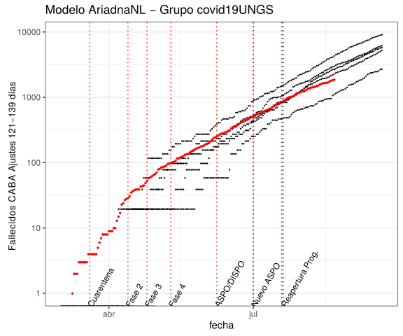

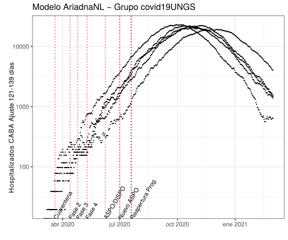

### Escenarios utilizando los parametros ajustados para 121-139 Días

| Escenario | beta | Horas en viaje | Horas en trabajo | proporción hospitalizados | Proporción fallecimiento hospitalizados |
| --- | --- | --- | --- | --- | --- |
| 1 | 0.41 | 2.4 | 7.5 | 0.19 | 0.092 |
| 2 | 0.41 | 2.0 | 5.00 | 0.19 | 0.092 |
| 3 | 0.41 | 2.74 | 2.11 | 0.19 | 0.092 |
| 4 | 0.41 | 1.00 | 2.00 | 0.19 | 0.092 |

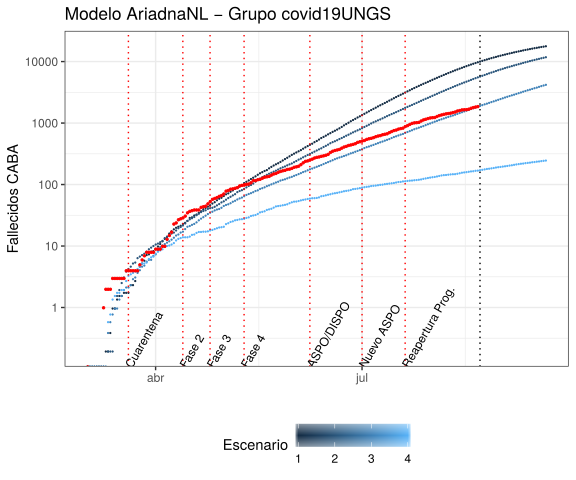

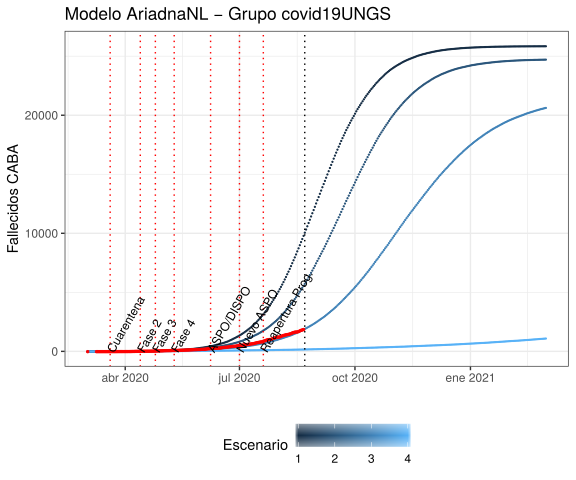

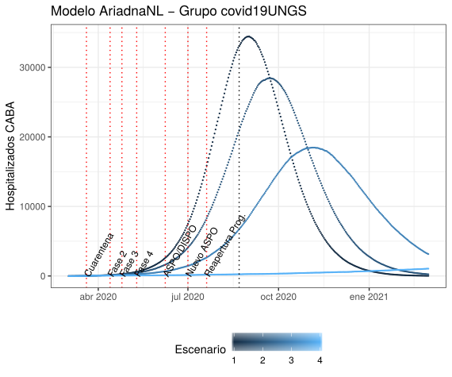

- Para comparación al dia 21/08 la cantidad de camas ocupadas total en CABA = 2691 = 1697+713+281 (Leves+moderados+graves)

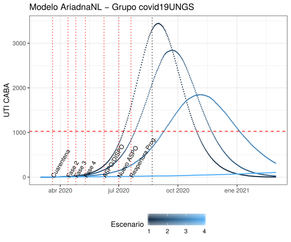

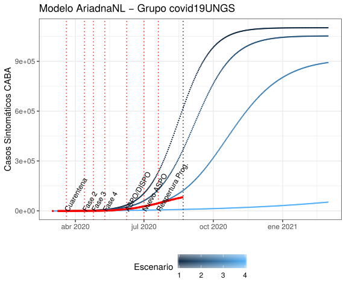

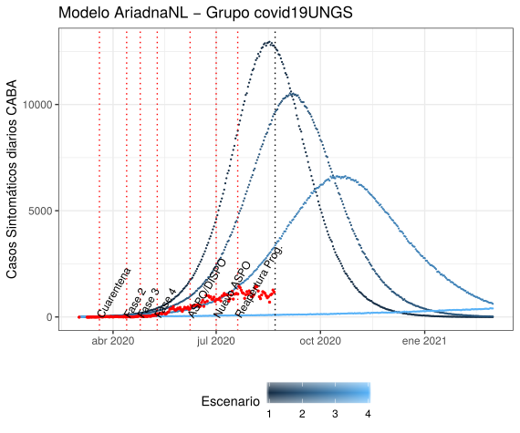

## Resultados y discusión

- Observando los ajustes y escenarios de CABA
  - A partir de los 121 días (01/07/2020) no hay cambios en los parámetros ajustados
  - Como las medidas de aislamiento van modificando la dinámica de la epidemia es muy poco probable que un ajuste con un set de parámetros fijos pueda predecir con certeza el desarrollo de la misma.
  - En los escenarios se observa que aunque los fallecimientos ajustan razonablemente bien, la cantidad de casos diarios y hospitalizados es mucho menor, con lo cual probablemente haya variaciones en los parámetros de fallecidos y hospitalizados